# What could 50,000 voters achieve?

Tristan Snowsill

2020-06-04

The death toll from COVID-19 in the UK has passed 50,000. This is a tragedy that is hard to comprehend.

Or you can picture 50 secondary schools or 500 orchestras.

I wondered out of interest what political power 50,000 people could have.

It turns out that if you take the 2019 UK General Election results and swing 50,000 Conservative voters in precisely chosen constituencies to the second-place party, 52 Conservative MPs would lose their seats.

Here is the current political map:

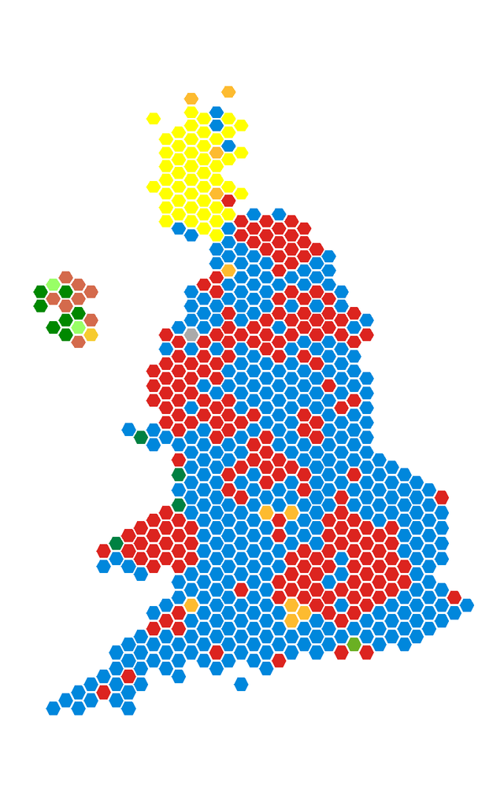

Here is what it looks like in the scenario described:

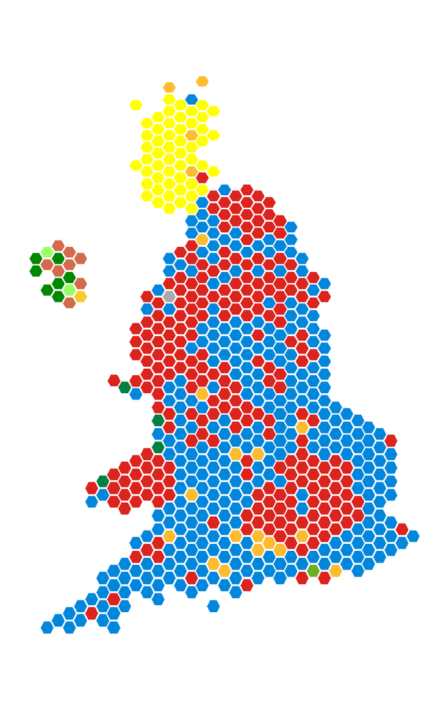

In this scenario 39 seats flip to Labour (now at 241), 9 flip to the Liberal Democrats (now at 20) and 4 flip to the SNP (now at 52). There is a hung parliament with the Conservatives having 313 MPs. A rainbow coalition of Labour (241), SNP (52), Liberal Democrats (20), Plaid Cymru (4), SDLP (2), Green (1) and Alliance(1) has a total 321 votes. A Conservative (313) – DUP (8) coalition would also have 321 votes. A very hung parliament, with neither of those coalitions appearing easy to form.

An alternative scenario is that all Conservative supporters stick with the Conservatives, but 50,000 voters who did not vote Conservative in 2019 switch to vote tactically. In this scenario the Conservatives lose 38 seats (29 to Labour, 6 to Liberal Democrats and 3 to SNP).

The point here is not that these scenarios are likely. For one thing, we know that people who have died can no longer vote, let alone swing tactically. We also must not assume that just because COVID-19 is more likely to kill the elderly and that the elderly are more likely to vote Conservative that those killed are more likely to be Conservative voters, or have family who are.

Perhaps the point is simply that 50,000 voters out of a total electorate exceeding 47 million can have a disproportionate impact under first past the post, and politicians are more acutely aware of that than most.